# Analysis of spatio-temporal data, WS 2019/20, Oct 21

## Reminder

1. What is correlation? \[r(x,y) = \frac{\sum_{i=1}^n(x_i-\bar{x})(y_i-\bar{y})}{\sqrt{\sum_{i=1}^n(x_i-\bar{x})^2 \sum_{i=1}^n(y_i-\bar{y})^2}}\]
   - symmetric
   - measuring linear relationship
   - bound by [-1,1]
2. What is linear regression? \[y = b_0 + b_1 x + e\]
   - asymmetric
   - \(y\) is dependent (random), \(x\) is independent (non-random)
   - \(b_0\) and \(b_1\) are not bound, but have measurement units of \(y\) (\(b_0\)) or relating \(x\) to \(y\) (\(b_1\))

## Literature

The first two articles in [R News 2/2](https://www.r-project.org/doc/Rnews/Rnews_2002-2.pdf), “Time Series in R 1.5.0” and “Naive Time Series Forecasting Methods” provide some introduction to the topics discussed below. A more extensive text, focused on forecasting, is Hyndman and Athanasopoulos' [Forecasting: Principles and Practice](https://otexts.org/fpp2/)

## Time series: time domain, autocorrelation, AR, MA

We disinguish continuous time processes

\[y(t), t \in [T_1,T_2]\]

from time events

\[\{t_1,t_2,…,t_n\} t \in [T_1,T_2].\]

Regular time series data are samples (or aggregations over a time interval) \(y(t_i)\) taken from the process, with \(t_{i+1}-t_i\) constant: the time interval. If this is the case, we typically write \(y(t_i)\) as \(y_i\).

We will now give examples using datasets available in R.

An example of the first type is

```r
print(co2,digits=3)
```

```
##      Jan Feb Mar Apr May Jun Jul Aug Sep Oct Nov Dec
## 1959 315 316 316 318 318 318 316 315 314 313 315 315
## 1960 316 317 317 319 320 319 318 316 314 314 315 316
## 1961 317 318 318 319 320 320 318 317 315 315 316 317
## 1962 318 318 320 320 321 320 319 317 316 315 317 318
## 1963 319 319 320 321 322 321 320 318 316 316 317 318
## 1964 319 320 321 321 322 322 320 319 317 317 318 319
## 1965 319 320 321 322 322 322 321 319 318 317 319 319
## 1966 320 321 322 324 324 324 322 320 318 318 320 321
## 1967 322 322 323 324 325 324 322 321 319 319 321 322
## 1968 322 323 324 325 325 325 324 322 320 320 321 323
## 1969 324 324 325 326 327 327 326 324 322 322 323 324
## 1970 325 326 327 328 328 328 326 325 323 323 324 325
## 1971 326 327 327 328 329 328 327 325 323 323 325 326
## 1972 327 327 328 330 330 329 328 326 325 325 326 327
```

[output cut: 25 more lines]

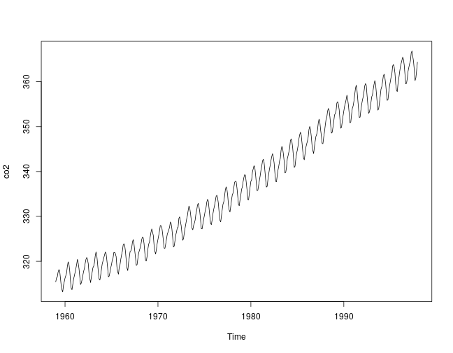

```r
plot(co2)
```

It concerns monthly values of CO\(_2\) in the air, measured at the Mauna Loa volcano, starting in 1959. See here here for more recent data.

Another data set gives times of events of the Old Faithful geyser in Yellowstone National Park (USA); the first six records are

```r
head(faithful)
```

```
##   eruptions waiting
## 1     3.600      79
## 2     1.800      54
## 3     3.333      74
## 4     2.283      62
## 5     4.533      85
## 6     2.883      55
```

the first variable is the eruption duration (mins), the second the time to the next eruption. This means that we get actual times \(t_i\)

```r
time.mins <- cumsum(apply(faithful, 1, sum))
time.mins[1:10]
```

```
##       1       2       3       4       5       6       7       8       9
##  82.600 138.400 215.733 280.016 369.549 427.432 520.132 608.732 661.682
##      10
## 751.032
```

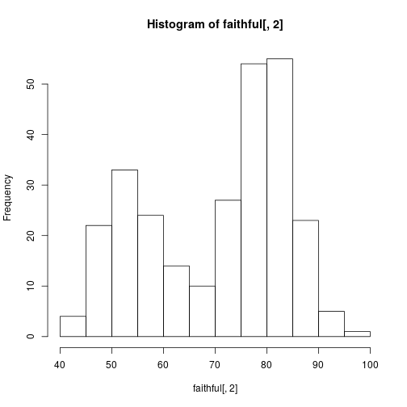

```r
hist(faithful[,2])
```

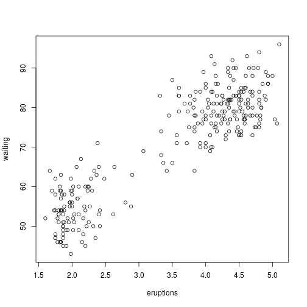

```r
plot(faithful)
```

and even a bivariate bimodal distribution:

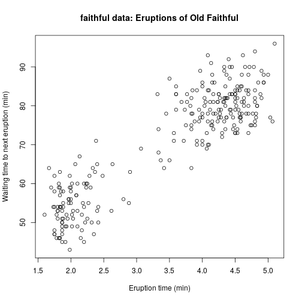

```r
plot(faithful[, -3], main = "faithful data: Eruptions of Old Faithful",
  xlab = "Eruption time (min)",
  ylab = "Waiting time to next eruption (min)")
```

We will concentrate here, on time series of the first kind.

## Ozone

Ozone data from the `airquality` dataset have missing values:

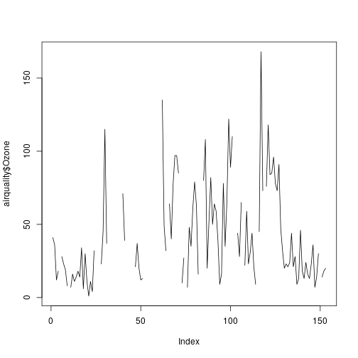

```r
plot(airquality$Ozone, type = 'l')
```

We can remove these by

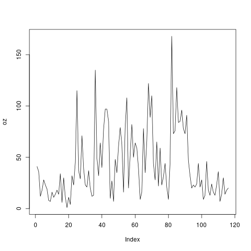

```r
oz = na.omit(airquality$Ozone)
plot(oz, type = 'l')
```

which essentially “glues” the series together, horizontally. This is **not**, in general, a good idea. Try to think of reasons why not.

The series obtained looks rather messy. A question that arises, is whether this series can be considered to be purely random, or whether there is some structure in it.

We can generate similar series that are unstructured by randomly resampling the same variable; function `sample` does this:

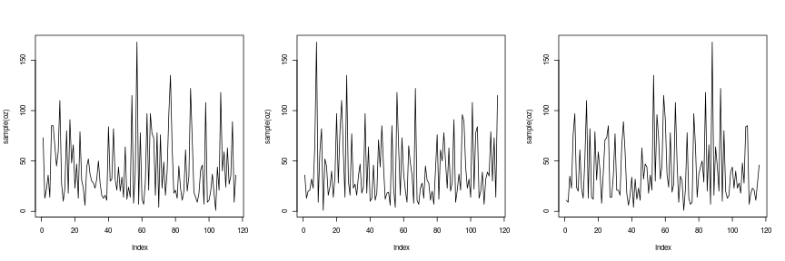

```r
par(mfrow = c(1,3))
plot(sample(oz), type = 'l')
plot(sample(oz), type = 'l')
plot(sample(oz), type = 'l')
```

```r
par(mfrow = c(1,1))
```

are the resulting patterns similar, or are they more random than the real `Ozone` series?

## Temporal correlation

Temporal correlation investigates whether two observations \(y_i\) and \(y_{i+1}\) are correlated. We can compute this correlation, and plot it, by

```r
cor(head(oz, -1), tail(oz, -1))
```

```
## [1] 0.4648286
```

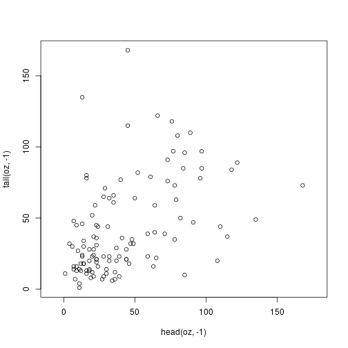

```r
plot(head(oz, -1), tail(oz, -1), asp = 1)
```

The correlation is moderate, but not extremely high. Could it be caused by random chance? We can generate random correlations *from this dataset*, by generating 1000 correlations of random permutations, and compute the 2.5 and 97.5 percentiles:

```r
corrs = sapply(1:1000, function(x) cor(head(sample(oz), -1), tail(sample(oz), -1)))
quantile(corrs, c(.025, .975))
```

```
##       2.5%      97.5%
## -0.1918945  0.1978781
```

This indicates that a correlation of 0.45 cannot be considered random. The ozone series is temporally correlated.

## Autocorrelation, partial autocorrelation

The above autocorrelation is the lag-1 autocorrelation. We can also compute lag-2, lag-3, … autocorrelations, and plot them:

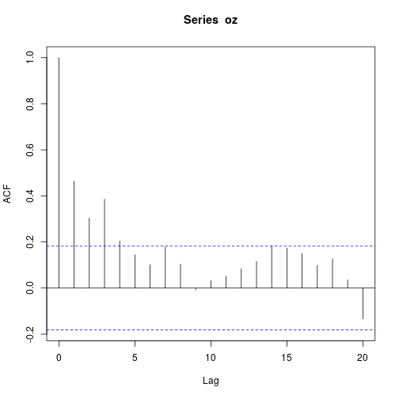

```r
acf(oz)
```

where, trivially, the lag-0 autocorrelation is 1. The blue lines indicate the bounds between which autocorrelation are not significantly different from zero.

If the lag-1 autocorrelation is high, automatically the lag-2 autocorrelation will be high too. But are \(y_i\) and \(y_{i+2}\) still correlated if we would correct for the lat-1 autocorrelation? Partial autocorrelation computes this:

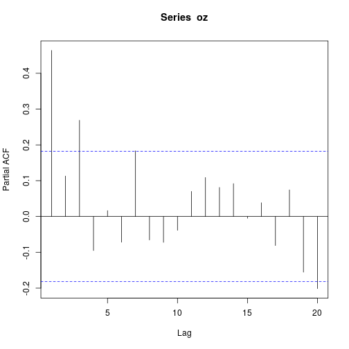

```r
pacf(oz)
```

which shows that partial autocorrelation for lag 2 is not significant.

An example where autocorrelation is high, but partial autocorrelation beyond lag 1 is zero, is that of random walk, where \(y_{i+1}=y_i + e_i\) with \(e_i\) an independent random variable:

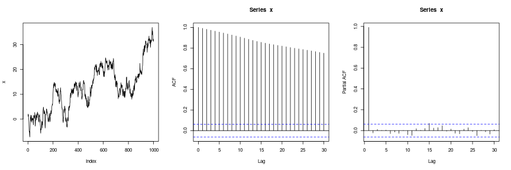

```r
par(mfrow = c(1,3))
x = cumsum(rnorm(1000))
plot(x, type = 'l')
acf(x)
pacf(x)
```

```r
par(mfrow = c(1,1))
```

An example where lag-1 autocorrelation is negative is found in the faithful data:

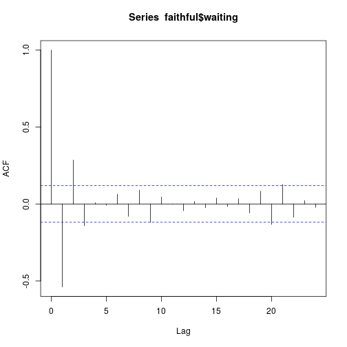

```r
acf(faithful$waiting) # $
```

In case of a regular periodicity, such as in a sinus function, we see alternating (periodic) effects in the acf too:

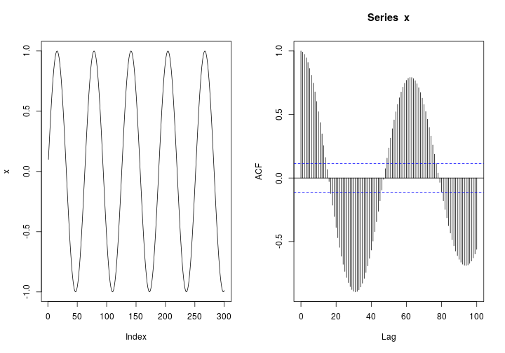

```r
par(mfrow = c(1,2))
x = sin(1:300/10)
plot(x, type = 'l')
acf(x, 100)
```

```r
par(mfrow = c(1,1))
```

Why is the autocorrelation at lag 60 not equal to 1? Try also with a set ranging from 1 to 3000.

## Autoregressive models, moving average models

Autoregressive models relate observations to their previous values:

\[y_i = \sum_{j=1}^p \phi_j y_{i-j} + e_i\]

Moving average models relate observations to a moving average of previous noise values:

\[y_i = \sum_{k=1}^q \theta_k e_{i-k} + e_i\]

## Trend models

Trend effects can be take out by computing differences, recursively. For instance, if the data contains a mean, \(y_t = \mu + e_t\), the first-order differences \(y_{t+1}-y_t\) will have zero mean. If the data contains a linear trend in time, \(y_t = \mu + \beta t + e_t\), the first-order difference will have mean equal to \(\beta\), the second order difference, \((y_{t+2}-y_{t+1})-(y_{t+1}-y_t) = y_{t+2}-2y_{t+1}+y_t\) will have zero mean. We can define the difference operator, \(B^i(y)\) as taking the $i-$th order difference:

\[B^0(y_t) = y_t\]

\[B^1(y_t) = y_{t+1}-y_t\]

\[B^2(y_t) = B^1(B^1(y_t)) = y_{t+2}-2y_{t+1}+y_t\]

Illustration:

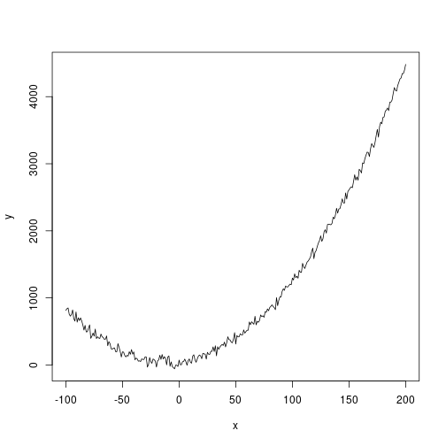

```r
x = -100:200
y = 50 + 2.0 * x + 0.1 * x^2 + rnorm(301)*50
plot(x, y, type = 'l')
```

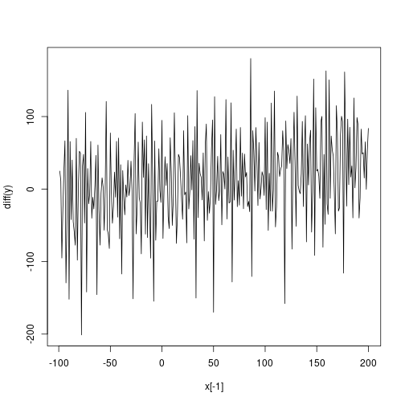

```r
plot(x[-1], diff(y), type = 'l')
```

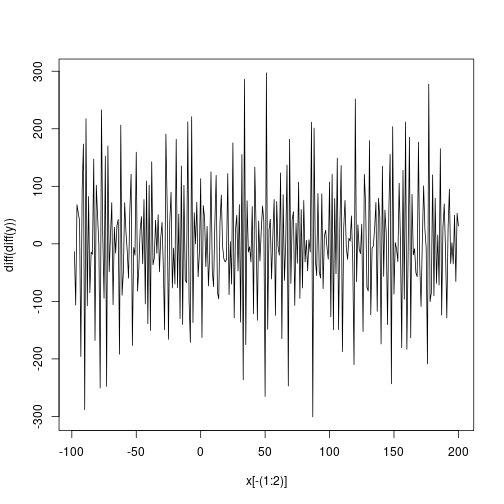

```r
plot(x[-(1:2)], diff(diff(y)), type = 'l')
```

```r
mean(diff(diff(y)))
```

```
## [1] 0.1970021
```

What would you expect as value for the mean of the twice-differenced series?

## arima(p,d,q)

The arima(p,d,q) model is then obtained by fitting an AR(p) model and an MA(q) model to \(d\)-th order differences:

\[B^d(y_t) = \sum_{j=1}^p \phi_j y_{i-j} + \sum_{k=1}^q \theta_k e_{i-k} + e_t\]

## Automatic model fitting

A function to autoatically select \(p\), \(d\) and \(q\) and estimate the corresponding model is found in `forecast`:

```r
library(forecast)
auto.arima(oz)
## Series: oz
## ARIMA(0,0,3) with non-zero mean
##
## Coefficients:
##          ma1     ma2     ma3     mean
##       0.3834  0.1553  0.3839  41.9343
## s.e.  0.0864  0.0837  0.0930   4.8938
##
## sigma^2 estimated as 791.3:  log likelihood=-549.95
## AIC=1109.9   AICc=1110.45   BIC=1123.67
```

## Further reading, next steps

- [Here](https://people.duke.edu/%7Ernau/411arim.htm) is a more extensive explanation of the arima models, arima modelling and use in prediction/forecasting
- arima models do not include any seasonality
- we can fit known seasonalities using e.g. Holt-Winters models, or stl (“seasonal, trend and irregular components using loess”)
- we can identify periodicities by using harmonic analysis

## Exercises

E1. Generate a random series with white noise added to a second order trend, as was done above; choose and fit an ARIMA model to it using `forecast::auto.arima`, and verify (discuss) whether the model chosen is in accordance to the process you simulated.

```r
x = -100:200
y = 50 + 2.0 * x + 0.1 * x^2 + rnorm(301)*50
forecast::auto.arima(y)
## Series: y
## ARIMA(1,2,3)
##
## Coefficients:
##           ar1      ma1      ma2     ma3
##       -0.5821  -1.2432  -0.2433  0.5210
## s.e.   2.3966   2.3894   4.3963  2.0587
##
## sigma^2 estimated as 2633:  log likelihood=-1602.96
## AIC=3215.92   AICc=3216.12   BIC=3234.42
```

E2. Repeat this, but make the second order (parabolic) component so small that it is hardly visible in a plot; use `auto.arima` again and discuss the outcome.

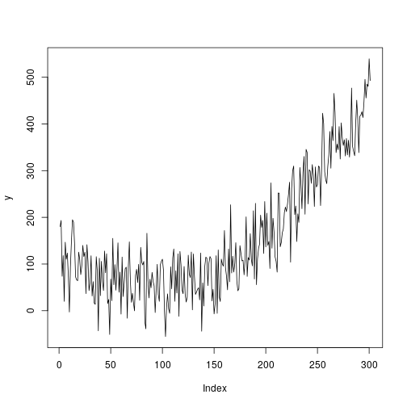

```r
#set.seed(111)
x = -100:200
y = 50 + 0.2 * x + 0.01 * x^2 + rnorm(301)*50
plot(y, type = 'l')
```

```r
forecast::auto.arima(y)
## Series: y
## ARIMA(2,1,1) with drift
##
## Coefficients:
##           ar1     ar2      ma1   drift
##       -0.0094  0.0320  -0.8523  1.1756
## s.e.   0.0671  0.0648   0.0337  0.4724
##
## sigma^2 estimated as 2858:  log likelihood=-1617.98
## AIC=3245.97   AICc=3246.17   BIC=3264.49
```

E3. Use `forecast::auto.arima` to choose and fit an ARIMA model to the `co2` time series, interpret the resulting model and coefficients; do read into the documentation of parameter `seasonal` to find out what an sar[x] parameter refers to.

```r
# see https://otexts.com/fpp2/seasonal-arima.html
forecast::auto.arima(co2)
## Series: co2
## ARIMA(1,1,1)(1,1,2)[12]
##
## Coefficients:
##          ar1      ma1     sar1     sma1     sma2
##       0.2569  -0.5847  -0.5489  -0.2620  -0.5123
## s.e.  0.1406   0.1204   0.5880   0.5701   0.4819
##
## sigma^2 estimated as 0.08576:  log likelihood=-84.39
## AIC=180.78   AICc=180.97   BIC=205.5
```

E4. Repeat this, but switch off the fitting of a seasonal component.

```r
# see https://otexts.com/fpp2/seasonal-arima.html
forecast::auto.arima(co2, seasonal = FALSE)
## Series: co2
## ARIMA(2,1,1) with drift
##
## Coefficients:
##          ar1      ar2      ma1   drift
##       1.5519  -0.8550  -0.9272  0.1055
## s.e.  0.0239   0.0237   0.0129  0.0070
##
## sigma^2 estimated as 0.3808:  log likelihood=-436.73
## AIC=883.47   AICc=883.6   BIC=904.2
```

E5. Create an `stl` decomposition of `co2` with `plot(stl(co2, "periodic"))`, and try to interpret the result

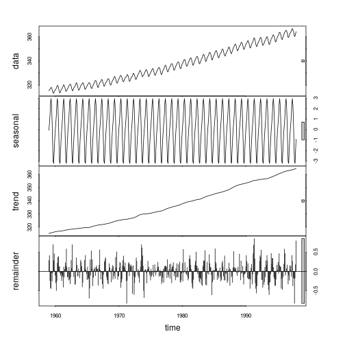

```r
plot(stl(co2, "periodic"))
```

E6. Use the dataset `air`, obtained by `data(air, package = "spacetime")`; compute the autocorrelation function and partial autocorrelation function for the first air quality station (omitting missing values as was done above with dataset `airquality`)

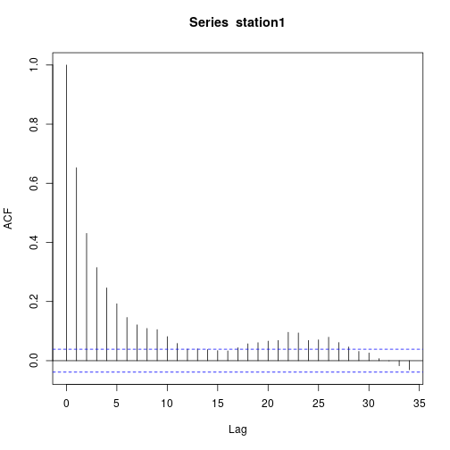

```r
data(air, package = "spacetime")
station1 = na.omit(air[1,])
acf(station1)
```

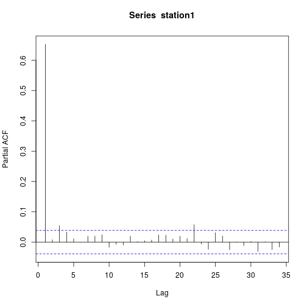

```r
pacf(station1)
```

E7. As an alternative to skipping missing values, use `zoo::na.approx` to linearly interpolate them in cases of gaps, and repeat the last exercise.

```r
library(zoo)
```

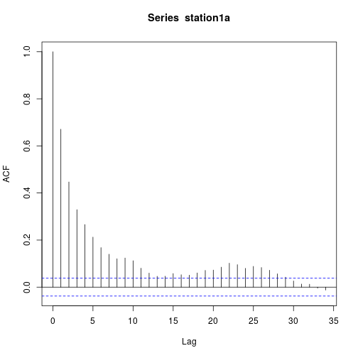

```r
station1a = na.approx(air[1,])
acf(station1a)
```

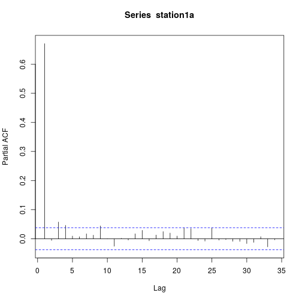

```r
pacf(station1a)
```